# IODS course project

David Rosson

# Introduction to Open Data Science - Course Project

# About the project

> How are you feeling right now?

Apprehensive about the uncertainties of the future.

> What do you expect to learn?

Basic R tasks.

> Where did you hear about the course?

Sisu.

It seems the book has a lot of content, probably quite useful.

I’m familiar with Markdown but not with R.

Repo link: https://github.com/gartenfeld/IODS-project

```r
# This is a so-called "R chunk" where you can write R code.

date()
```

```
## [1] "Mon Nov 27 17:17:28 2023"
```

# Week 2: Wrangle & Analyse

*This week we follow through the examples in Exercise Set 2 and learn about how to do linear regression and beyond with R.*

A few words about the data set:

```r
date()
```

```
## [1] "Mon Nov 27 17:17:28 2023"
```

### Step 1: Read the data

```r
library(readr)
data <- read_csv('data/learning_2014.csv')
str(data)
```

```
## spc_tbl_ [166 × 7] (S3: spec_tbl_df/tbl_df/tbl/data.frame)
##  $ gender  : chr [1:166] "F" "M" "F" "M" ...
##  $ age     : num [1:166] 53 55 49 53 49 38 50 37 37 42 ...
##  $ attitude: num [1:166] 3.7 3.1 2.5 3.5 3.7 3.8 3.5 2.9 3.8 2.1 ...
##  $ deep    : num [1:166] 3.58 2.92 3.5 3.5 3.67 ...
##  $ stra    : num [1:166] 3.38 2.75 3.62 3.12 3.62 ...
##  $ surf    : num [1:166] 2.58 3.17 2.25 2.25 2.83 ...
##  $ points  : num [1:166] 25 12 24 10 22 21 21 31 24 26 ...
##  - attr(*, "spec")=
##   .. cols(
##   ..   gender = col_character(),
##   ..   age = col_double(),
##   ..   attitude = col_double(),
##   ..   deep = col_double(),
##   ..   stra = col_double(),
##   ..   surf = col_double(),
##   ..   points = col_double()
##   .. )
##  - attr(*, "problems")=<externalptr>
```

```r
dim(data)
```

```
## [1] 166   7
```

The data contains 166 survey responses. Each response contains 7 columns (variables), namely: gender, age of the participant, attitude score (being the average of 10 attitude questions about attitudes towards learning about statistics), deep/surface/strategic metrics (the average of different categories of questions related to learning approaches or methods) – see more details in this [document](https://www.mv.helsinki.fi/home/kvehkala/JYTmooc/JYTOPKYS3-meta.txt) and the points from some exam or test.

So the general gist is – you may have guessed it – what influences study outcomes in statistics? Is it attitude towards learning? Is it approach and life hacks in learning? Let’s find out.

### Step 2: Graphical overview

“Show a graphical overview”, a “plot of everything”:

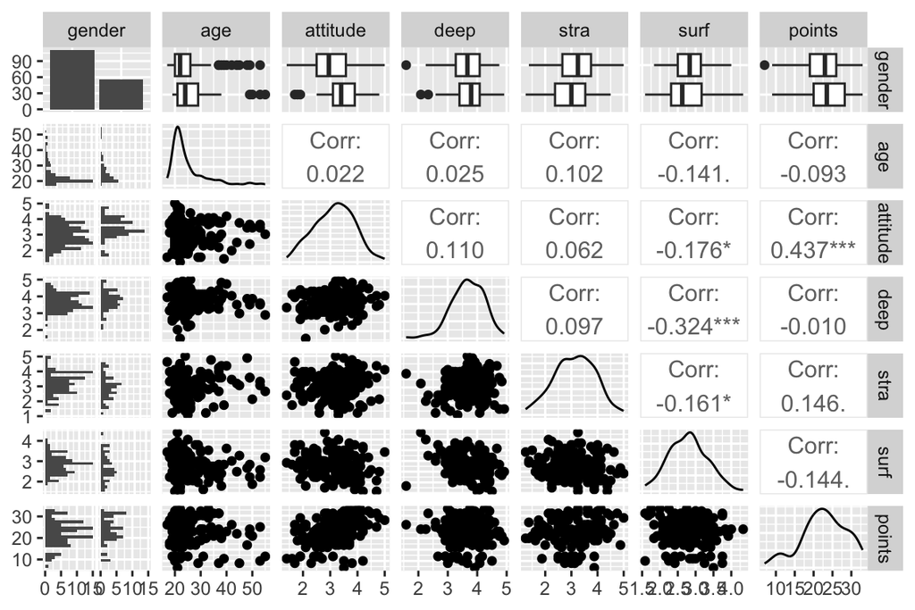

```r
library(GGally)
library(ggplot2)
p <- ggpairs(data, mapping = aes(), lower = list(combo = wrap("facethist", bins = 20)))
p
```

The histograms (on the left-hand side) are quite useful for showing the distributions, we can see for example at a glance there are actually a lot of younger students who answered the survey, even though the first few rows have older people.

The box plots show how gender correlate with the other variables.

The scatter plots are not so easy for humans to eyeball the trends.

But, what’s most interesting for us may be the vertical strip of printouts where “points” correlate with other variables.

### Step 3: Fit a model

Let’s pick the three largest values: `attitude`, `stra`, `surf`

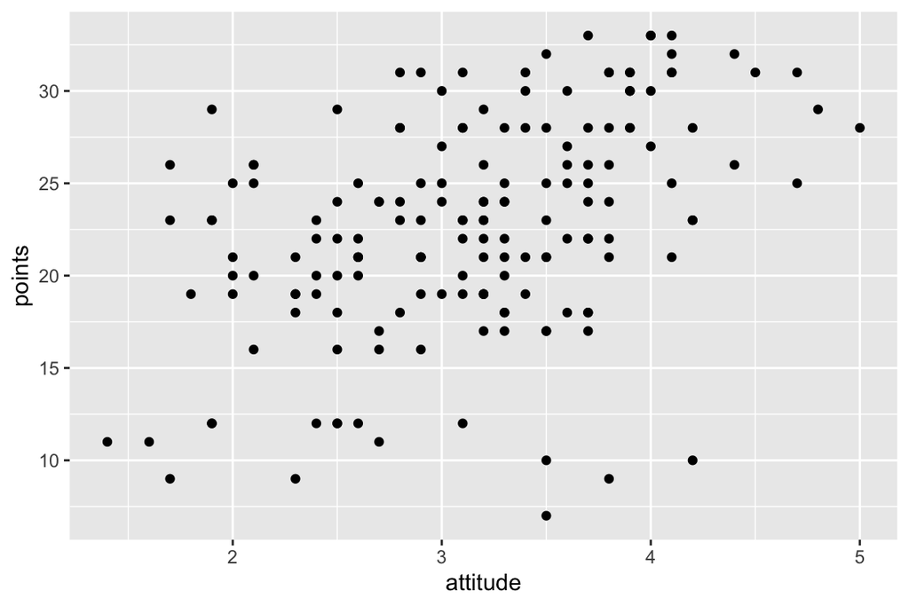

```r
p1 <- ggplot(data, aes(x = attitude, y = points))
p2 <- p1 + geom_point()
p2
```

Seems a bit all over the place. Let’s add a regression line:

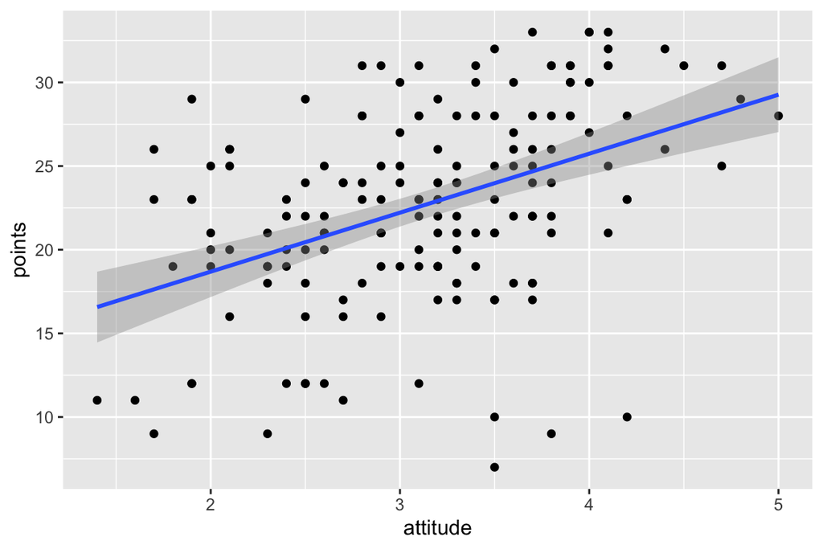

```r
p3 <- p2 + geom_smooth(method = "lm")
# Draw plot
p3
```

Now, onto fitting a regression model with all three variables!

```r
multi_model <- lm(points ~ attitude + stra + surf, data = data)
multi_model
```

```
##
## Call:
## lm(formula = points ~ attitude + stra + surf, data = data)
##
## Coefficients:
## (Intercept)     attitude         stra         surf
##     11.0171       3.3952       0.8531      -0.5861
```

```r
summary(multi_model)
```

```
##
## Call:
## lm(formula = points ~ attitude + stra + surf, data = data)
##
## Residuals:
##      Min       1Q   Median       3Q      Max
## -17.1550  -3.4346   0.5156   3.6401  10.8952
##
## Coefficients:
##             Estimate Std. Error t value Pr(>|t|)
## (Intercept)  11.0171     3.6837   2.991  0.00322 **
## attitude      3.3952     0.5741   5.913 1.93e-08 ***
## stra          0.8531     0.5416   1.575  0.11716
## surf         -0.5861     0.8014  -0.731  0.46563
## ---
## Signif. codes:  0 '***' 0.001 '**' 0.01 '*' 0.05 '.' 0.1 ' ' 1
##
## Residual standard error: 5.296 on 162 degrees of freedom
## Multiple R-squared:  0.2074, Adjusted R-squared:  0.1927
## F-statistic: 14.13 on 3 and 162 DF,  p-value: 3.156e-08
```

### Step 4: Interpretation

Looking at the fitted coefficients (r-squareds), attitude has a big influence, stra has a much smaller influence, surf has a smaller still and negative influence.

### Step 5: Graphical validation

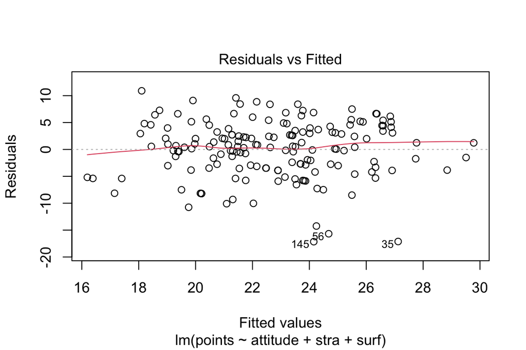

```r
# Residuals vs Fitted values (1)
p_a = plot(multi_model, which = 1)
```

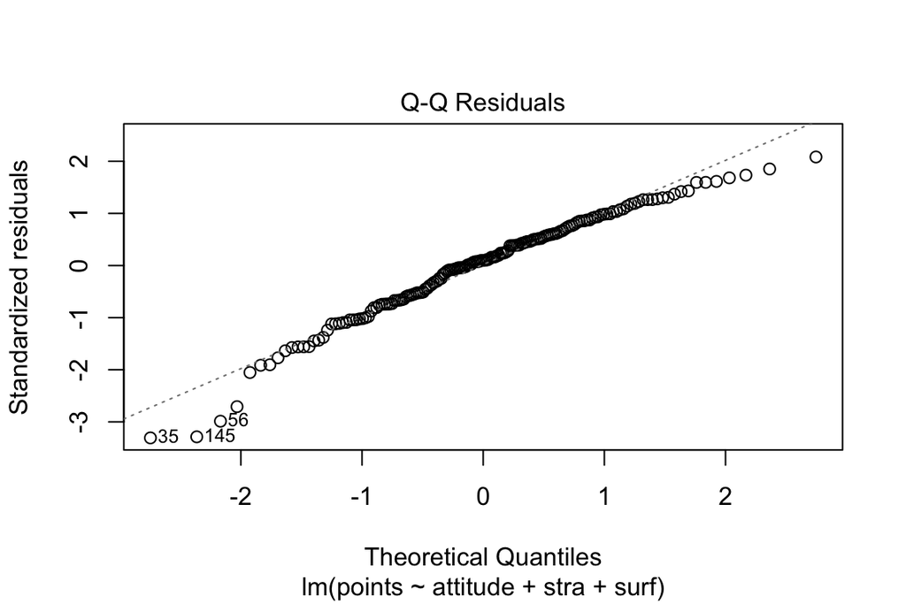

```r
# Normal QQ-plot (2)
p_b = plot(multi_model, which = 2)
```

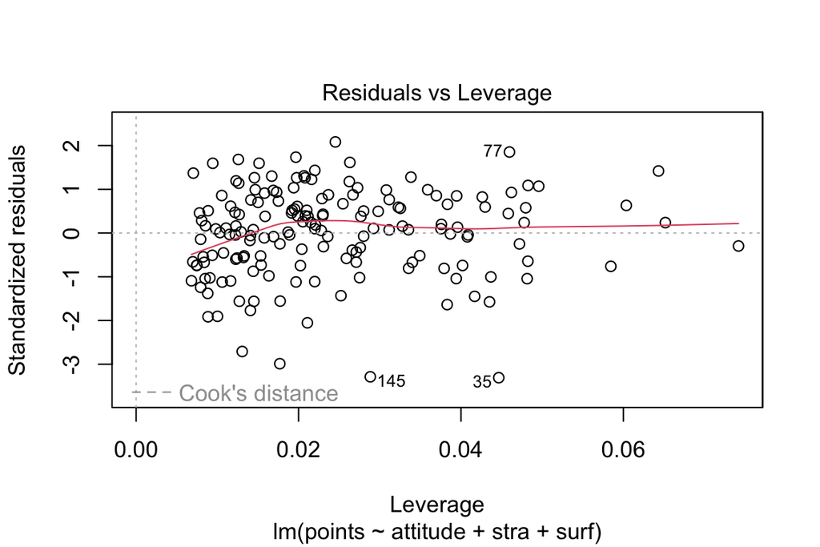

```r
# Residuals vs Leverage (5)
p_c = plot(multi_model, which = 5)
```

According to the internet, the assumptions of a linear model include:

- Outcome variables have errors, X is fixed
- Errors are independent
- Errors distribute normally
- Errors have constant variance
- X to mean Y is linear

These are basically saying that the overall assumption of a linear model is that there is a linear relationship between the distribution of the outcome dots and the input 🤷‍♀️ Yeah, sounds tautological but a (sp)line only makes sense if a plausible underlying causal line exists… And when it does exist the dots tend to have a evenly spread shape.

The quantile-quantile looks pretty close to the prediction. Residuals seem quite evenly spread across, maybe slightly top-heavy. There are a bunch of points that have high leverage/influence on the outcome.

# Week 3

*This week we follow through the examples in Exercise Set 3.*

```r
date()
```

```
## [1] "Mon Nov 27 17:17:31 2023"
```

### Step 1

Create this file and include it in `index.Rmd`.

### Step 2

> Read the joined student alcohol consumption data into R

```r
library(readr)
data <- read_csv('data/drunk_kids.csv')
```

> Print out the names of the variables in the data

```r
names(data)
```

```
##  [1] "school"     "sex"        "age"        "address"    "famsize"
##  [6] "Pstatus"    "Medu"       "Fedu"       "Mjob"       "Fjob"
## [11] "reason"     "guardian"   "traveltime" "studytime"  "schoolsup"
## [16] "famsup"     "activities" "nursery"    "higher"     "internet"
## [21] "romantic"   "famrel"     "freetime"   "goout"      "Dalc"
## [26] "Walc"       "health"     "failures"   "paid"       "absences"
## [31] "G1"         "G2"         "G3"         "alc_use"    "high_use"
```

> Describe the data set briefly, assuming the reader has no previous knowledge of it

The data is about high-schoolers in Portugal and their grades. The two datasets are from two subjects: maths and Portugese. G1 and G2 are from the first two periods, G3 is the final grade. The questionnaire includes a bunch of socio-economic, behavioural, and other factors. In this exercise we wonder if binge drinking kids have worse study outcomes.

> The purpose of your analysis is to study the relationships between high/low alcohol consumption and some of the other variables in the data. To do this, choose 4 interesting variables in the data and for each of them, present your personal hypothesis about their relationships with alcohol consumption.

Choices of variables and reasoning:

- `sex`: interesting to see if there’s a gender difference in consumption
- `romantic`: cool kids drink more often and socialise more
- `famrel`: kids with bad family relationship drink more
- `goout`: kids go out with friends and drink

> Numerically and graphically explore the distributions of your chosen variables and their relationships with alcohol consumption (use for example cross-tabulations, bar plots and box plots). Comment on your findings and compare the results of your exploration to your previously stated hypotheses.

```r
library(dplyr)
data %>% count(sex)
```

```
## # A tibble: 2 × 2
##   sex       n
##   <chr> <int>
## 1 F       195
## 2 M       175
```

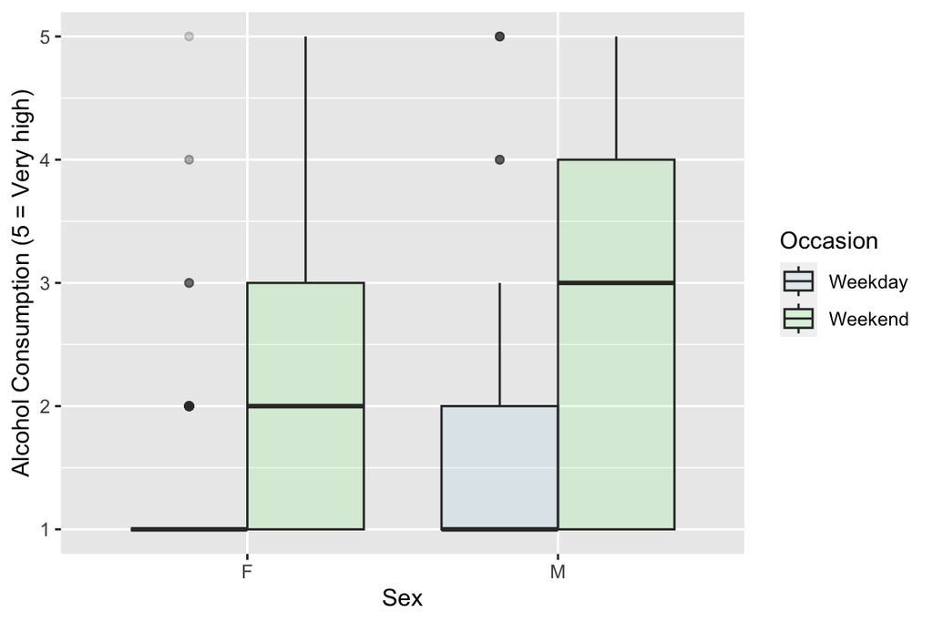

```r
library(ggplot2)

data_for_plot <- tidyr::gather(data, key = "timing", value = "combined_use", Dalc, Walc)


ggplot(data_for_plot, aes(x = sex, y = combined_use, fill = timing)) +
  geom_boxplot(position = "dodge", alpha = 0.2) +

  labs(
       x = "Sex",
       y = "Alcohol Consumption (5 = Very high)",
       fill = "Occasion",
  ) +

  scale_fill_manual(
    values = c("Dalc" = "lightblue", "Walc" = "lightgreen"),
    labels = c("Dalc" = "Weekday", "Walc" = "Weekend")
  )
```

Comments:

- Boys drink more
- Girls rarely drink during the week
- There may be a significant difference between the sexes

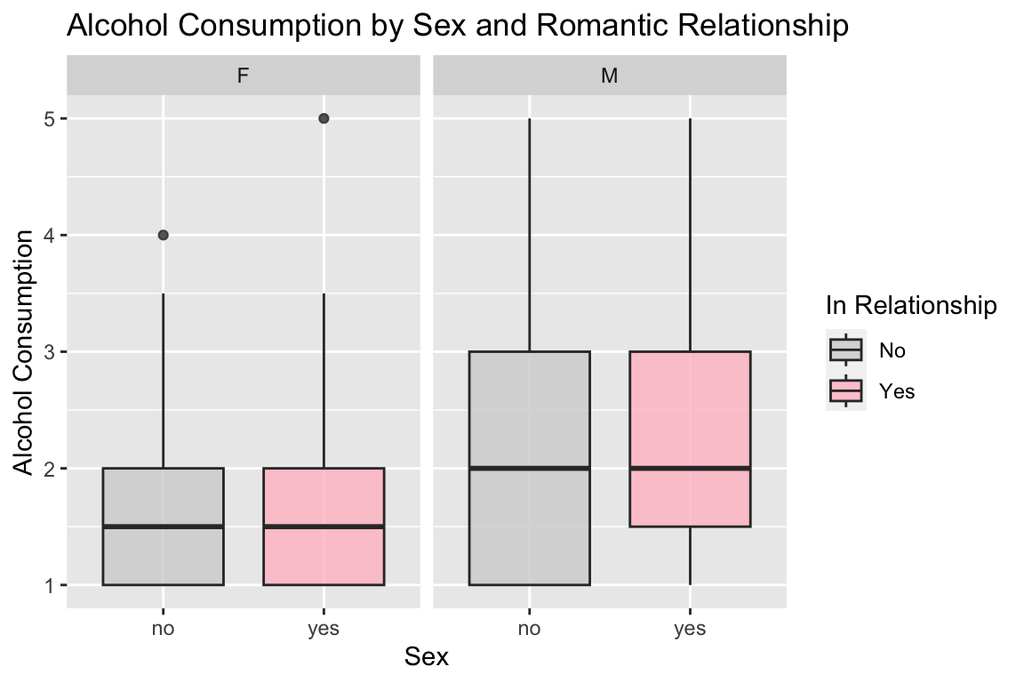

```r
library(ggplot2)

ggplot(data, aes(x = romantic, y = alc_use, fill = romantic)) +
  geom_boxplot(position = position_dodge(0.8), alpha = 0.8) +
  labs(title = "Alcohol Consumption by Sex and Romantic Relationship",
       x = "Sex",
       y = "Alcohol Consumption",
       fill = "Romantic") +
  scale_fill_manual(values = c("yes" = "pink", "no" = "lightgrey"),
                    name = "In Relationship",
                    labels = c("yes" = "Yes", "no" = "No")) +
  facet_grid(. ~ sex)
```

Comments:

- Alcohol makes no difference in girls
- It also makes almost no difference in boys
- Therefore one cannot drink one’s way to pair bonding

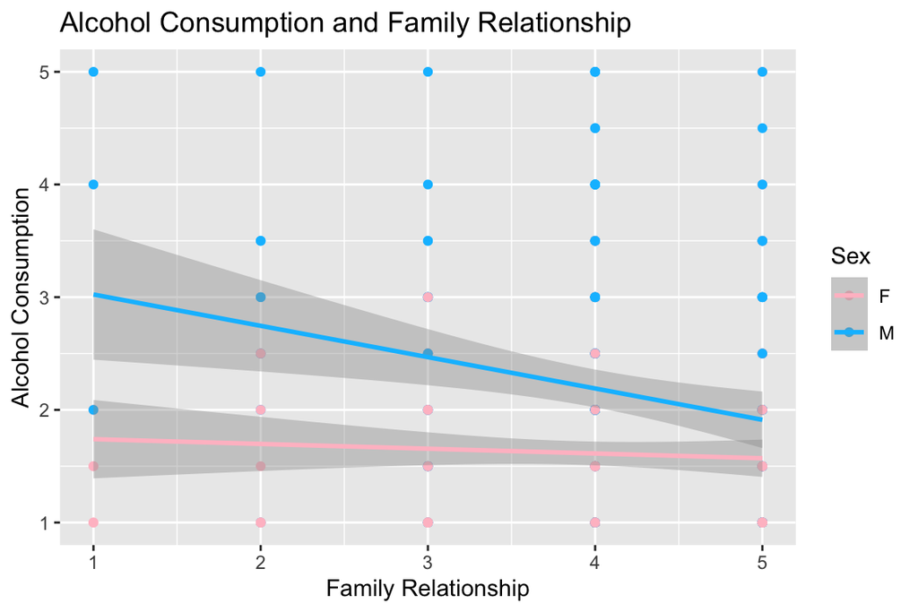

```r
library(ggplot2)

ggplot(data, aes(x = famrel, y = alc_use, color = sex)) +
  geom_point() +
  geom_smooth(method = "lm") +
  labs(title = "Alcohol Consumption and Family Relationship",
       x = "Family Relationship",
       y = "Alcohol Consumption",
       color = "Sex") +
  scale_color_manual(values = c("M" = "deepskyblue", "F" = "pink"),
                     name = "Sex")
```

Comments:

- For boys, the trend seems more noticeable, that one drinks less in a good family
- For girls the line seems pretty flat, that all family environments have relatively low drinking

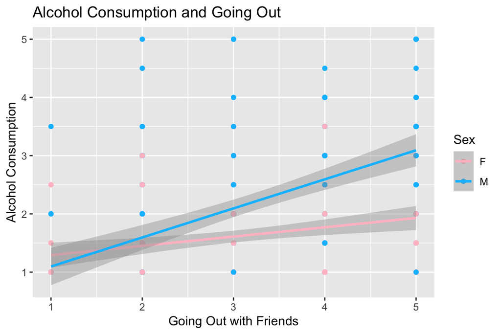

```r
library(ggplot2)

ggplot(data, aes(x = goout, y = alc_use, color = sex)) +
  geom_point() +
  geom_smooth(method = "lm") +
  labs(title = "Alcohol Consumption and Going Out",
       x = "Going Out with Friends",
       y = "Alcohol Consumption",
       color = "Sex") +
  scale_color_manual(values = c("M" = "deepskyblue", "F" = "pink"),
                     name = "Sex")
```

Comments:

- Quite obvious trends of going out involving drinking

### Step 5

> Use logistic regression to statistically explore the relationship between your chosen variables and the binary high/low alcohol consumption variable as the target variable.

```r
alco_predictor <- glm(high_use ~ famrel + goout, data = data, family = "binomial")
```

> Present and interpret a summary of the fitted model.

```r
summary(alco_predictor)
```

```
##
## Call:
## glm(formula = high_use ~ famrel + goout, family = "binomial",
##     data = data)
##
## Coefficients:
##             Estimate Std. Error z value Pr(>|z|)
## (Intercept)  -1.9404     0.6179  -3.140  0.00169 **
## famrel       -0.3891     0.1350  -2.882  0.00395 **
## goout         0.7923     0.1193   6.640 3.14e-11 ***
## ---
## Signif. codes:  0 '***' 0.001 '**' 0.01 '*' 0.05 '.' 0.1 ' ' 1
##
## (Dispersion parameter for binomial family taken to be 1)
##
##     Null deviance: 452.04  on 369  degrees of freedom
## Residual deviance: 394.65  on 367  degrees of freedom
## AIC: 400.65
##
## Number of Fisher Scoring iterations: 4
```

Interpretation:

- Family relationship goodness has a significant negative influence on high use
- Going out with friends has a significant positive influence on high use

```r
coef(alco_predictor)
```

```
## (Intercept)      famrel       goout
##  -1.9403921  -0.3890518   0.7923023
```

Interpretation:

- An increase in `goout` is associated with an increase in the log-odds of `high_use`, while an increase in `famrel` is associated with a decrease in the log-odds of `high_use`.

### Step 6

> Using the variables which, according to your logistic regression model, had a statistical relationship with high/low alcohol consumption, explore the predictive power of you model. Provide a 2x2 cross tabulation of predictions versus the actual values and optionally display a graphic visualizing both the actual values and the predictions.

```r
alco_predictor <- glm(high_use ~ famrel + goout, data = data, family = "binomial")
probs <- predict(alco_predictor, type = "response")

library(dplyr)
forwards_data <- mutate(data, probability = probs)
forwards_data <- mutate(forwards_data, prediction = probability > 0.5)

table(high_use = forwards_data$high_use, prediction = forwards_data$prediction)
```

```
##         prediction
## high_use FALSE TRUE
##    FALSE   233   26
##    TRUE     64   47
```

> Compute the total proportion of inaccurately classified individuals (= the training error) and comment on all the results.

```r
TP <- 47
TN <- 233
FP <- 26
FN <- 64
training_error <- (FP + FN) / (TP + TN + FP + FN)
training_error
```

```
## [1] 0.2432432
```

> Compare the performance of the model with performance achieved by some simple guessing strategy.

So it gets a quarter of the cases wrong. Personally, I’m not sure what is a “simple guessing strategy”, it’s better than a coin toss, but given the input of family relationship and going out, plus some human intuition, guessing could have fared better or worse. But 75+% correct classification seems to be a rather good first-try result in machine learning learning land.

### Step 7

> Perform 10-fold cross-validation on your model.

```r
data$high_use <- as.factor(data$high_use)
alco_predictor <- glm(high_use ~ famrel + goout, data = data, family = "binomial")

# Run `install.packages('caret', dependencies = TRUE)` beforehand
library(caret)
# Create a training control object for 10-fold cross-validation
ctrl <- trainControl(method = "cv", number = 10)

# Perform cross-validation using caret
cv_results <- train(high_use ~ famrel + goout, data = data, method = "glm", family = "binomial", trControl = ctrl)

# View cross-validation results
cv_results
```

```
## Generalized Linear Model
##
## 370 samples
##   2 predictor
##   2 classes: 'FALSE', 'TRUE'
##
## No pre-processing
## Resampling: Cross-Validated (10 fold)
## Summary of sample sizes: 332, 333, 333, 333, 333, 333, ...
## Resampling results:
##
##   Accuracy   Kappa
##   0.7485301  0.3225002
```

The prediction is 74% accurate and quite a bit better than chance.

The performance of this model is on par with the “model introduced in the Exercise Set (which had about 0.26 error)”.

### Step 8

> Perform cross-validation to compare the performance of different logistic regression models (= different sets of predictors). Start with a very high number of predictors and explore the changes in the training and testing errors as you move to models with less predictors. Draw a graph displaying the trends of both training and testing errors by the number of predictors in the model.

Noniin, let’s start with a “very high number of predictors”.

```r
data$high_use <- as.factor(data$high_use)
alco_predictor <- glm(high_use ~ address + famsize + Pstatus + Medu + Fedu + Mjob + Fjob + reason + guardian + traveltime + studytime + schoolsup + famsup + activities + nursery + higher + internet + romantic + freetime + health + failures + paid + absences + G1 + G2 + G3 + famrel + goout, data = data, family = "binomial")

# Run `install.packages('caret', dependencies = TRUE)` beforehand
library(caret)
# Create a training control object for 10-fold cross-validation
ctrl <- trainControl(method = "cv", number = 10)

# Perform cross-validation using caret
cv_results <- train(high_use ~ address + famsize + Pstatus + Medu + Fedu + Mjob + Fjob + reason + guardian + traveltime + studytime + schoolsup + famsup + activities + nursery + higher + internet + romantic + freetime + health + failures + paid + absences + G1 + G2 + G3 + famrel + goout, data = data, method = "glm", family = "binomial", trControl = ctrl)

# View cross-validation results
cv_results
```

```
## Generalized Linear Model
##
## 370 samples
##  28 predictor
##   2 classes: 'FALSE', 'TRUE'
##
## No pre-processing
## Resampling: Cross-Validated (10 fold)
## Summary of sample sizes: 333, 334, 333, 333, 333, 333, ...
## Resampling results:
##
##   Accuracy   Kappa
##   0.7404971  0.3417139
```

Not much better…

Now, with hand-picked variables:

```r
data$high_use <- as.factor(data$high_use)
alco_predictor <- glm(high_use ~ address + Pstatus + higher + absences + famrel + goout, data = data, family = "binomial")

# Run `install.packages('caret', dependencies = TRUE)` beforehand
library(caret)
# Create a training control object for 10-fold cross-validation
ctrl <- trainControl(method = "cv", number = 10)

# Perform cross-validation using caret
cv_results <- train(high_use ~ address + Pstatus + higher + absences + famrel + goout, data = data, method = "glm", family = "binomial", trControl = ctrl)

# View cross-validation results
cv_results
```

```
## Generalized Linear Model
##
## 370 samples
##   6 predictor
##   2 classes: 'FALSE', 'TRUE'
##
## No pre-processing
## Resampling: Cross-Validated (10 fold)
## Summary of sample sizes: 333, 333, 333, 333, 333, 333, ...
## Resampling results:
##
##   Accuracy   Kappa
##   0.7486486  0.3145781
```

After manually trying a bunch of combos, it doesn’t seem to get much better than this… due to the random round-robin cross-validation, the value also jumps up and down making it hard to eyeball whether it’s better or worse.

But wait, what about…

```r
data$high_use <- as.factor(data$high_use)
alco_predictor <- glm(high_use ~ Walc + Dalc, data = data, family = "binomial")

# Run `install.packages('caret', dependencies = TRUE)` beforehand
library(caret)
# Create a training control object for 10-fold cross-validation
ctrl <- trainControl(method = "cv", number = 10)

# Perform cross-validation using caret
cv_results <- train(high_use ~ Walc + Dalc, data = data, method = "glm", family = "binomial", trControl = ctrl)

# View cross-validation results
cv_results
```

```
## Generalized Linear Model
##
## 370 samples
##   2 predictor
##   2 classes: 'FALSE', 'TRUE'
##
## No pre-processing
## Resampling: Cross-Validated (10 fold)
## Summary of sample sizes: 334, 333, 333, 333, 333, 333, ...
## Resampling results:
##
##   Accuracy  Kappa
##   1         1
```

Well, statistical truths are often tautological.

# Week 4

*This week we follow through the examples in Exercise Set 4.*

```r
date()
```

```
## [1] "Mon Nov 27 17:17:32 2023"
```

### Step 1

Create this file and include it in `index.Rmd`.

### Step 2

> “Load the Boston data from the MASS package”

```r
# Load MASS package
library(MASS)
data("Boston")
```

> “Explore the structure and the dimensions of the data”

```r
str(Boston)
```

```
## 'data.frame':    506 obs. of  14 variables:
##  $ crim   : num  0.00632 0.02731 0.02729 0.03237 0.06905 ...
##  $ zn     : num  18 0 0 0 0 0 12.5 12.5 12.5 12.5 ...
##  $ indus  : num  2.31 7.07 7.07 2.18 2.18 2.18 7.87 7.87 7.87 7.87 ...
##  $ chas   : int  0 0 0 0 0 0 0 0 0 0 ...
##  $ nox    : num  0.538 0.469 0.469 0.458 0.458 0.458 0.524 0.524 0.524 0.524 ...
##  $ rm     : num  6.58 6.42 7.18 7 7.15 ...
##  $ age    : num  65.2 78.9 61.1 45.8 54.2 58.7 66.6 96.1 100 85.9 ...
##  $ dis    : num  4.09 4.97 4.97 6.06 6.06 ...
##  $ rad    : int  1 2 2 3 3 3 5 5 5 5 ...
##  $ tax    : num  296 242 242 222 222 222 311 311 311 311 ...
##  $ ptratio: num  15.3 17.8 17.8 18.7 18.7 18.7 15.2 15.2 15.2 15.2 ...
##  $ black  : num  397 397 393 395 397 ...
##  $ lstat  : num  4.98 9.14 4.03 2.94 5.33 ...
##  $ medv   : num  24 21.6 34.7 33.4 36.2 28.7 22.9 27.1 16.5 18.9 ...
```

```r
dim(Boston)
```

```
## [1] 506  14
```

> “Describe the dataset briefly, assuming the reader has no previous knowledge of it.”

The dataset comes from a study by Harrison and Rubinfeld (1978) on house prices in Boston suburbs. It’s commonly used for teaching stats (specifically regression analysis, often called “machine learning” these days) by examples of predicting real estate prices from a number of demographic and socio-economic factors. The dataset contains 506 observations (rows) and 13 predictor variables plus the dependent variable (`medv`, **med**ian **v**alue of owner-occupied homes). See [documentation](https://stat.ethz.ch/R-manual/R-devel/library/MASS/html/Boston.html).

### Step 3

> “Show a graphical overview of the data”

[figure not shown]

```r
library(GGally)
library(ggplot2)
library(dplyr)
p <- ggpairs(Boston)
p
```

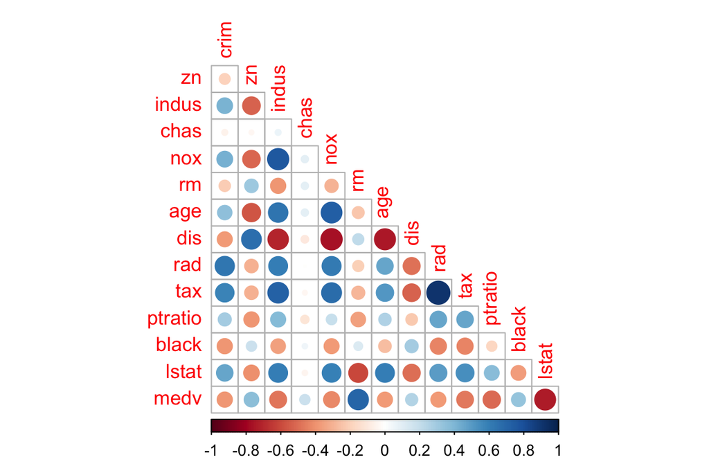

```r
cor_matrix <- cor(Boston) %>% round(digits = 2)
library(corrplot)
corrplot(cor_matrix, method="circle", diag = FALSE, type = 'lower')
```

> “Show summaries of the variables in the data”

```r
summary(Boston)
```

```
##       crim                zn             indus            chas
##  Min.   : 0.00632   Min.   :  0.00   Min.   : 0.46   Min.   :0.00000
##  1st Qu.: 0.08205   1st Qu.:  0.00   1st Qu.: 5.19   1st Qu.:0.00000
##  Median : 0.25651   Median :  0.00   Median : 9.69   Median :0.00000
##  Mean   : 3.61352   Mean   : 11.36   Mean   :11.14   Mean   :0.06917
##  3rd Qu.: 3.67708   3rd Qu.: 12.50   3rd Qu.:18.10   3rd Qu.:0.00000
##  Max.   :88.97620   Max.   :100.00   Max.   :27.74   Max.   :1.00000
##       nox               rm             age              dis
##  Min.   :0.3850   Min.   :3.561   Min.   :  2.90   Min.   : 1.130
##  1st Qu.:0.4490   1st Qu.:5.886   1st Qu.: 45.02   1st Qu.: 2.100
##  Median :0.5380   Median :6.208   Median : 77.50   Median : 3.207
##  Mean   :0.5547   Mean   :6.285   Mean   : 68.57   Mean   : 3.795
##  3rd Qu.:0.6240   3rd Qu.:6.623   3rd Qu.: 94.08   3rd Qu.: 5.188
##  Max.   :0.8710   Max.   :8.780   Max.   :100.00   Max.   :12.127
##       rad              tax           ptratio          black
##  Min.   : 1.000   Min.   :187.0   Min.   :12.60   Min.   :  0.32
##  1st Qu.: 4.000   1st Qu.:279.0   1st Qu.:17.40   1st Qu.:375.38
##  Median : 5.000   Median :330.0   Median :19.05   Median :391.44
##  Mean   : 9.549   Mean   :408.2   Mean   :18.46   Mean   :356.67
##  3rd Qu.:24.000   3rd Qu.:666.0   3rd Qu.:20.20   3rd Qu.:396.23
##  Max.   :24.000   Max.   :711.0   Max.   :22.00   Max.   :396.90
##      lstat            medv
##  Min.   : 1.73   Min.   : 5.00
##  1st Qu.: 6.95   1st Qu.:17.02
##  Median :11.36   Median :21.20
##  Mean   :12.65   Mean   :22.53
##  3rd Qu.:16.95   3rd Qu.:25.00
##  Max.   :37.97   Max.   :50.00
```

> “Describe and interpret the outputs, commenting on the distributions of the variables and the relationships between them.

Looking at the bottom row `medv` as an example, we can see that `rm` (“average number of rooms per dwelling”) is strongly positively correlated with `medv` and that `lstat` (“lower status of the population in %”) is strongly negatively correlated. This is not surprising simply from reading the variable descriptions, that is, they are re-stating intuitive claims such as “larger houses cost more”, “poor people live in cheap neighbourhoods”.

### Step 4

> “Standardize the dataset and print out summaries of the scaled data.”

```r
boston_scaled <- scale(Boston)
summary(boston_scaled)
```

```
##       crim                 zn               indus              chas
##  Min.   :-0.419367   Min.   :-0.48724   Min.   :-1.5563   Min.   :-0.2723
##  1st Qu.:-0.410563   1st Qu.:-0.48724   1st Qu.:-0.8668   1st Qu.:-0.2723
##  Median :-0.390280   Median :-0.48724   Median :-0.2109   Median :-0.2723
##  Mean   : 0.000000   Mean   : 0.00000   Mean   : 0.0000   Mean   : 0.0000
##  3rd Qu.: 0.007389   3rd Qu.: 0.04872   3rd Qu.: 1.0150   3rd Qu.:-0.2723
##  Max.   : 9.924110   Max.   : 3.80047   Max.   : 2.4202   Max.   : 3.6648
##       nox                rm               age               dis
##  Min.   :-1.4644   Min.   :-3.8764   Min.   :-2.3331   Min.   :-1.2658
##  1st Qu.:-0.9121   1st Qu.:-0.5681   1st Qu.:-0.8366   1st Qu.:-0.8049
##  Median :-0.1441   Median :-0.1084   Median : 0.3171   Median :-0.2790
##  Mean   : 0.0000   Mean   : 0.0000   Mean   : 0.0000   Mean   : 0.0000
##  3rd Qu.: 0.5981   3rd Qu.: 0.4823   3rd Qu.: 0.9059   3rd Qu.: 0.6617
##  Max.   : 2.7296   Max.   : 3.5515   Max.   : 1.1164   Max.   : 3.9566
##       rad               tax             ptratio            black
##  Min.   :-0.9819   Min.   :-1.3127   Min.   :-2.7047   Min.   :-3.9033
##  1st Qu.:-0.6373   1st Qu.:-0.7668   1st Qu.:-0.4876   1st Qu.: 0.2049
##  Median :-0.5225   Median :-0.4642   Median : 0.2746   Median : 0.3808
##  Mean   : 0.0000   Mean   : 0.0000   Mean   : 0.0000   Mean   : 0.0000
##  3rd Qu.: 1.6596   3rd Qu.: 1.5294   3rd Qu.: 0.8058   3rd Qu.: 0.4332
##  Max.   : 1.6596   Max.   : 1.7964   Max.   : 1.6372   Max.   : 0.4406
##      lstat              medv
##  Min.   :-1.5296   Min.   :-1.9063
##  1st Qu.:-0.7986   1st Qu.:-0.5989
##  Median :-0.1811   Median :-0.1449
##  Mean   : 0.0000   Mean   : 0.0000
##  3rd Qu.: 0.6024   3rd Qu.: 0.2683
##  Max.   : 3.5453   Max.   : 2.9865
```

> “How did the variables change?”

They are now how many standard deviations either side, general 0 to 3, 3+ being the extremes.

> “Create a categorical variable of the crime rate in the Boston dataset (from the scaled crime rate).”

```r
boston_scaled <- as.data.frame(boston_scaled)
boston_scaled$crim <- as.numeric(boston_scaled$crim)
bins <- quantile(boston_scaled$crim)
```

> “Use the quantiles as the break points in the categorical variable.”

```r
quantile_labels <- c("low", "med_low", "med_high", "high")
crime <- cut(boston_scaled$crim, breaks = bins, labels = quantile_labels, include.lowest = TRUE)
boston_scaled <- data.frame(boston_scaled, crime)
```

> “Drop the old crime rate variable from the dataset.”

```r
boston_scaled <- dplyr::select(boston_scaled, -crim)
```

> “Divide the dataset to train and test sets, so that 80% of the data belongs to the train set.”

```r
num_observations <- nrow(boston_scaled)
sample_ids <- sample(num_observations,  size = num_observations * 0.8)
train_set <- boston_scaled[sample_ids,]
test_set <- boston_scaled[-sample_ids,]
```

# Step 5

```r
# the function for lda biplot arrows
lda.arrows <- function(x, myscale = 1, arrow_heads = 0.1, color = "red", tex = 0.75, choices = c(1,2)){
  heads <- coef(x)
  graphics::arrows(x0 = 0, y0 = 0,
         x1 = myscale * heads[,choices[1]],
         y1 = myscale * heads[,choices[2]], col=color, length = arrow_heads)
  text(myscale * heads[,choices], labels = row.names(heads),
       cex = tex, col=color, pos=3)
}
```

> “Fit the linear discriminant analysis on the train set. Use the categorical crime rate as the target variable and all the other variables in the dataset as predictor variables.”

```r
# `crime` as the target variable, and "." (all the others) as predicators
lda.fit <- lda(crime ~ ., data = train_set)
classes <- as.numeric(train_set$crime)
```

> “Draw the LDA biplot.”

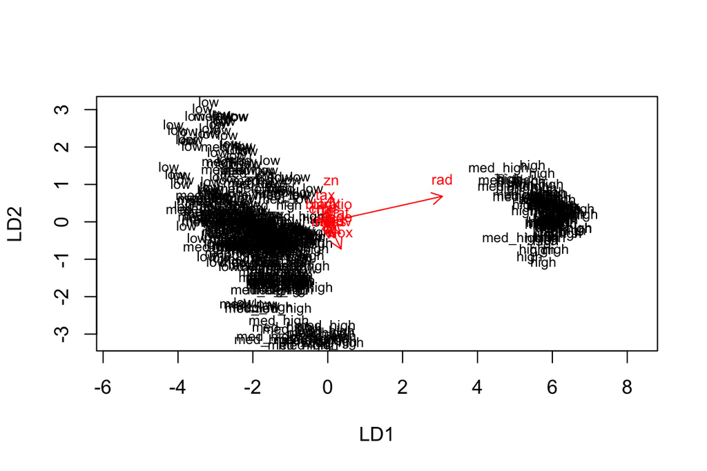

```r
plot(lda.fit, dimen = 2)
lda.arrows(lda.fit, myscale = 1)
```

### Step 6

> “Save the crime categories from the test set”

```r
correct_crime_level_predictions <- test_set$crime
```

> “Remove the categorical crime variable from the test dataset.”

```r
test_set <- dplyr::select(test_set, -crime)
```

> “Then predict the classes with the LDA model on the test data.”

```r
lda.pred <- predict(lda.fit, newdata = test_set)
```

> “Cross tabulate the results with the crime categories from the test set.”

```r
table(correct = correct_crime_level_predictions, predicted = lda.pred$class)
```

```
##           predicted
## correct    low med_low med_high high
##   low       21       3        2    0
##   med_low    8      19        4    0
##   med_high   0       5       15    0
##   high       0       0        0   25
```

### Step 7

> “Reload the Boston dataset.”

```r
library(MASS)
data("Boston")
```

> “Scale the variables to get comparable distances.”

```r
boston_scaled <- scale(Boston)
```

> “Calculate the distances between the observations.”

```r
dist_eu <- dist(boston_scaled)
```

> “Run k-means algorithm on the dataset.”

```r
km <- kmeans(boston_scaled, centers = 4)
```

> “Investigate what is the optimal number of clusters and run the algorithm again.”

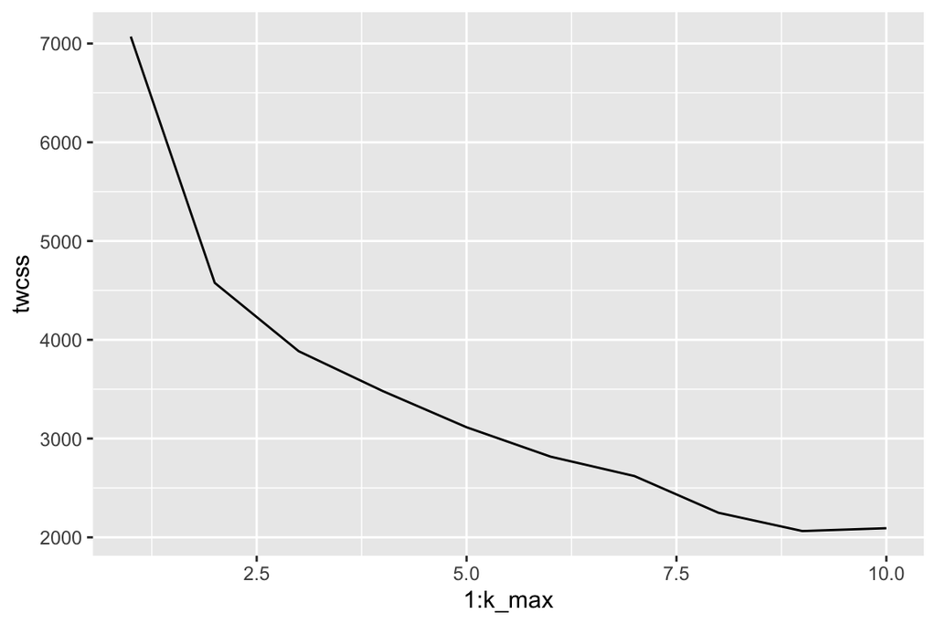

```r
set.seed(42)

k_max <- 10
twcss <- sapply(1:k_max, function(k){kmeans(boston_scaled, k)$tot.withinss})

# Spot the cliff
qplot(x = 1:k_max, y = twcss, geom = 'line')
```

> “Visualize the clusters”

[figure not shown]

```r
km <- kmeans(boston_scaled, centers = 2)
pairs(boston_scaled, col = km$cluster)
```

> “Interpret the results”

The idea of clustering observations into groups is predicated on the notion that there are natural or hidden categories in the observations, namely, we could ask “how many types of suburbs are there?” The grouping is easily spotted visually when – for simplicity’s sake, let’s imagine two classes – two classes have metrics that are well away from each other. We can then see on a scatter plot that one group is over here in one corner, and the other group is way over there in an opposite corner. In terms referred to in the above steps, that there is a great distance between those two clouds. Here we have more than 2 dimensions, we have a dozen or so variables, but that’s not a problem for the machine, similar principles apply – that is, we try to find groups that have centres away from each other, all these dimensions considered. The chart is a bit hard to read but upon zooming it you could see that sometimes the groups are more distinct.

### Extra

> “Perform k-means on the original Boston data with some reasonable number of clusters (> 2).”

```r
km <- kmeans(boston_scaled, centers = 3)
```

> “Then perform LDA using the clusters as target classes.”

```r
cluster <- km$cluster
boston_scaled <- data.frame(boston_scaled, cluster)
```

```r
summary(boston_scaled)
```

```
##       crim                 zn               indus              chas
##  Min.   :-0.419367   Min.   :-0.48724   Min.   :-1.5563   Min.   :-0.2723
##  1st Qu.:-0.410563   1st Qu.:-0.48724   1st Qu.:-0.8668   1st Qu.:-0.2723
##  Median :-0.390280   Median :-0.48724   Median :-0.2109   Median :-0.2723
##  Mean   : 0.000000   Mean   : 0.00000   Mean   : 0.0000   Mean   : 0.0000
##  3rd Qu.: 0.007389   3rd Qu.: 0.04872   3rd Qu.: 1.0150   3rd Qu.:-0.2723
##  Max.   : 9.924110   Max.   : 3.80047   Max.   : 2.4202   Max.   : 3.6648
##       nox                rm               age               dis
##  Min.   :-1.4644   Min.   :-3.8764   Min.   :-2.3331   Min.   :-1.2658
##  1st Qu.:-0.9121   1st Qu.:-0.5681   1st Qu.:-0.8366   1st Qu.:-0.8049
##  Median :-0.1441   Median :-0.1084   Median : 0.3171   Median :-0.2790
##  Mean   : 0.0000   Mean   : 0.0000   Mean   : 0.0000   Mean   : 0.0000
##  3rd Qu.: 0.5981   3rd Qu.: 0.4823   3rd Qu.: 0.9059   3rd Qu.: 0.6617
##  Max.   : 2.7296   Max.   : 3.5515   Max.   : 1.1164   Max.   : 3.9566
##       rad               tax             ptratio            black
##  Min.   :-0.9819   Min.   :-1.3127   Min.   :-2.7047   Min.   :-3.9033
##  1st Qu.:-0.6373   1st Qu.:-0.7668   1st Qu.:-0.4876   1st Qu.: 0.2049
##  Median :-0.5225   Median :-0.4642   Median : 0.2746   Median : 0.3808
##  Mean   : 0.0000   Mean   : 0.0000   Mean   : 0.0000   Mean   : 0.0000
##  3rd Qu.: 1.6596   3rd Qu.: 1.5294   3rd Qu.: 0.8058   3rd Qu.: 0.4332
##  Max.   : 1.6596   Max.   : 1.7964   Max.   : 1.6372   Max.   : 0.4406
##      lstat              medv            cluster
##  Min.   :-1.5296   Min.   :-1.9063   Min.   :1.000
##  1st Qu.:-0.7986   1st Qu.:-0.5989   1st Qu.:1.000
##  Median :-0.1811   Median :-0.1449   Median :2.000
##  Mean   : 0.0000   Mean   : 0.0000   Mean   :1.941
##  3rd Qu.: 0.6024   3rd Qu.: 0.2683   3rd Qu.:3.000
##  Max.   : 3.5453   Max.   : 2.9865   Max.   :3.000
```

> “Visualize the results with a bi-plot.”

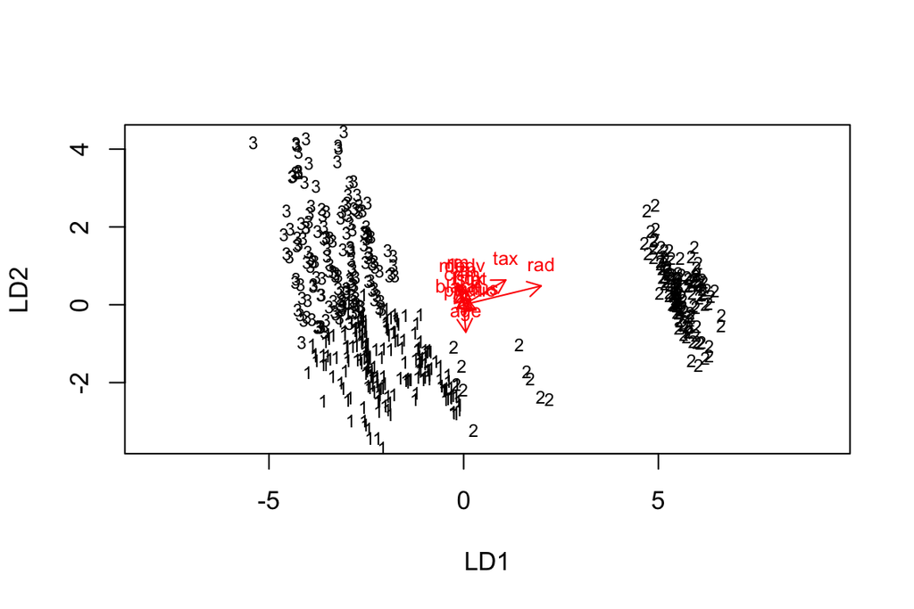

```r
lda.fit <- lda(cluster ~ ., data = boston_scaled[, -4])
plot(lda.fit, dimen = 2)
lda.arrows(lda.fit, myscale = 1)
```

#### Thank you and see you next week

(more chapters to be added similarly as we proceed with the course!)